# 5. ggplot2（散布図）

Masahiko Asano

2026-11-10

- **このセクションで使っている `R packages`**

```r
library(DT)
library(gapminder)
library(gghighlight)
library(ggrepel)
library(stargazer)
library(tidyverse)
```

# 1. 散布図とは

- 散布図 (`scatter plot`) は 2 つの連続変数（=間隔尺度、比率尺度で測定された変数）間の関係を調べる代表的な可視化方法
- 散布図は 2 次元平面上に複数の点を可視化したもの
- ここで使う幾何オブジェクトは `ggplot()` と `geom_point()`

| **幾何オブジェクト** | **意味** |
| --- | --- |
| **`ggplot()`** | 図を描くキャンバスを用意する |
| **`geom_point()`** | **散布図を描く** |

- 1996-2021年総選挙データから、2005年データを抜き出し「選挙費用」と「得票率」の散布図を描いてみる
- 必要なデータは次の 2 つ：
1. 選挙費用 (`exp`)
2. 得票率 (`voteshare`)
- データを読み込む
- hr96-26.csv をダウンロード

```r
df <- read_csv("data/hr96-26.csv",
               na = ".")
```

- 2005年データを抜き出し `df05` と名前を付ける

```r
df05 <- df %>%
  filter(year == 2005)
```

## 1.1 最もシンプルな散布図

- 横軸上の位置は `x` に、縦軸上の位置は `y` にマッピングする
- 2 つの変数の間に原因と結果の関係（因果関係）が考えられる2変数の場合  
  ・原因と考えられる要因を `x` 軸に設定（ここでは「選挙費用 `exp`」）  
  ・結果と考えられる要因を `y` 軸に設定（ここでは「得票率 `voteshare`」）

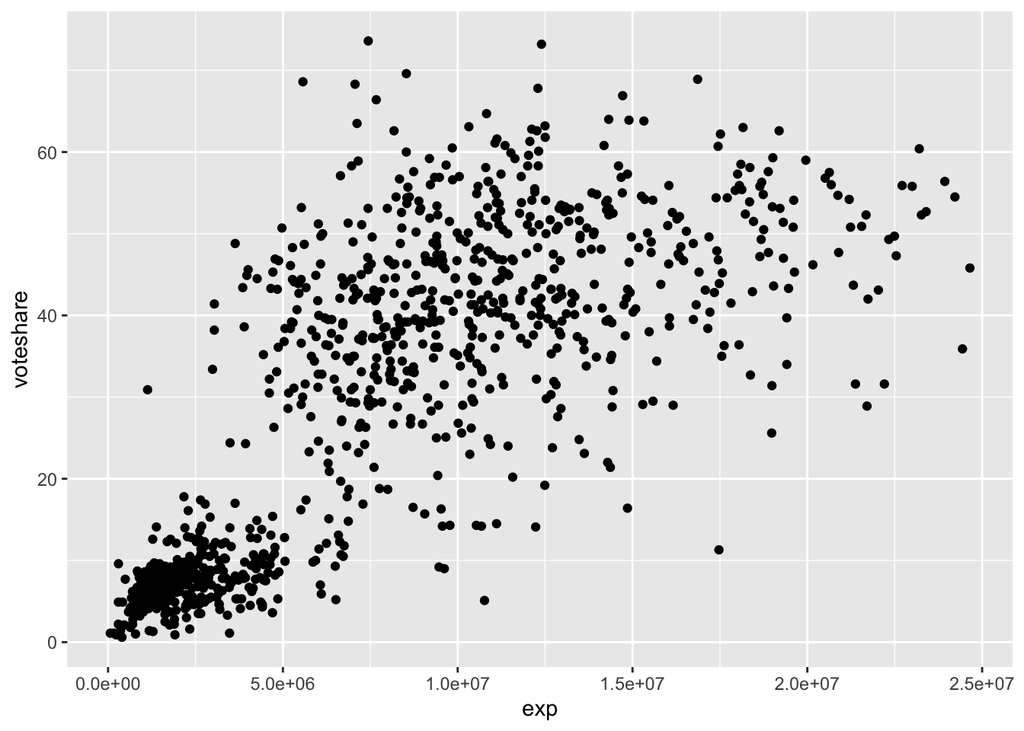

```r
df05 %>%
  ggplot() +
  geom_point(aes(x = exp,
                 y = voteshare))
```

- 横軸と縦軸のタイトルが `exp`, `votehsare`
- 図を見る人にはこれらが何を意味するか分からない  
  → x軸とy軸にラベルを付ける

### 回帰直線の引き方 (1)

- `aes()` の部分を `ggplot()` の内側に移動させる

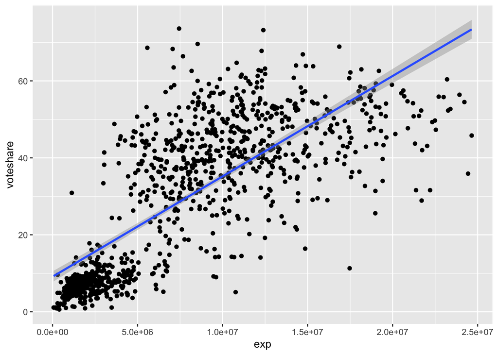

```r
df05 %>%
  ggplot(aes(x = exp,
                 y = voteshare)) +
  geom_point() +
  geom_smooth(method = "lm")
```

### 回帰直線の引き方 (2)

- `aes()` の部分を `geom_smooth()`の中にも書く

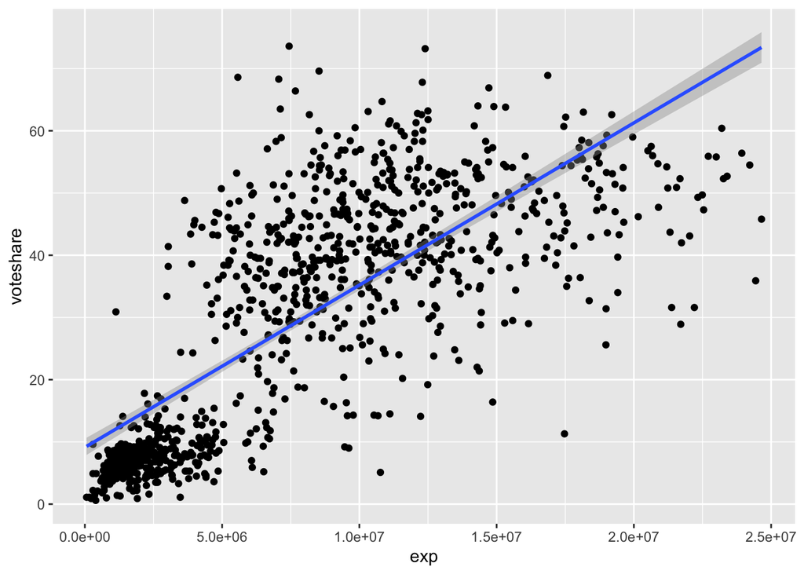

```r
df05 %>%
  ggplot() +
  geom_point(aes(x = exp, y = voteshare)) +
  geom_smooth(aes(x = exp, y = voteshare),
              method = "lm")
```

## 1.2 ラベルとドットの色をカスタマイズ

- `x` 軸と `y` 軸にラベルを付ける
- `ggtitle()` 関数を使ってメインタイトルを付ける
- ドットの色を指定する

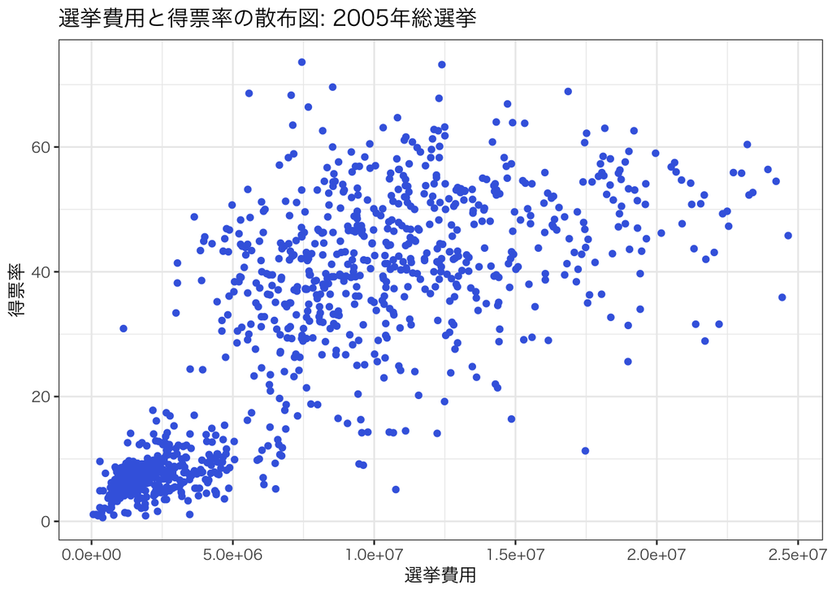

```r
df05 %>%
   ggplot() +
   geom_point(aes(x = exp,
                  y = voteshare),
              color = "royalblue") +
   labs(x = "選挙費用",
        y = "得票率") +
  ggtitle("選挙費用と得票率の散布図: 2005年総選挙") +
  theme_bw(base_family = "HiraKakuProN-W3")
```

## 1.3 ドットの形をカスタマイズ

- `shape = 番号` でドットの形を指定できる
- ここでは三角（`△`） に指定してみる

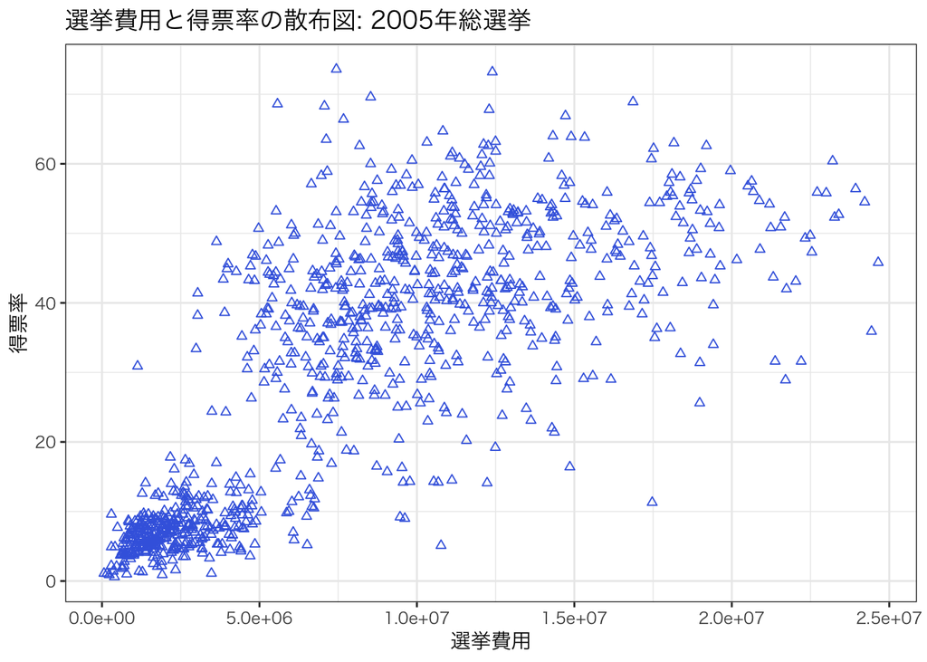

```r
df05 %>%
   ggplot() +
   geom_point(aes(x = exp,
                  y = voteshare),
              color = "royalblue",
              shape = 2) +
   labs(x = "選挙費用",
        y = "得票率") +
  ggtitle("選挙費用と得票率の散布図: 2005年総選挙") +
  theme_bw(base_family = "HiraKakuProN-W3")
```

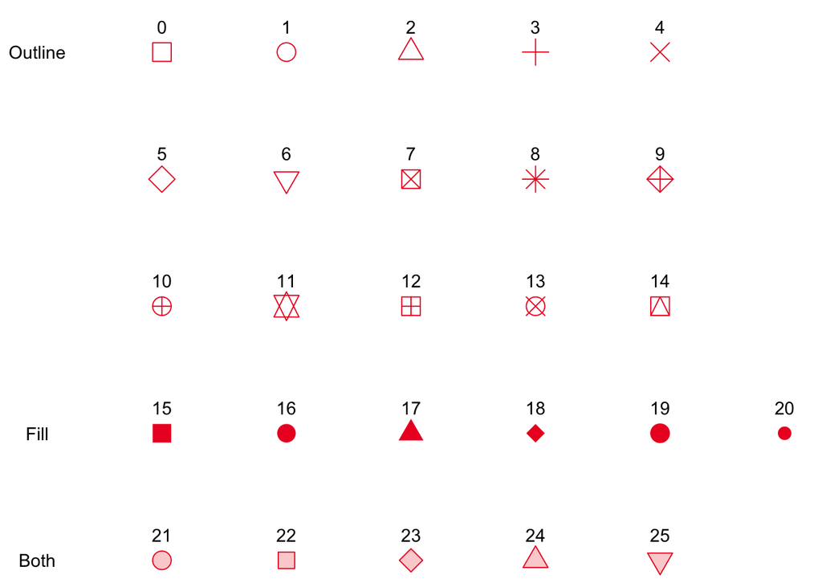

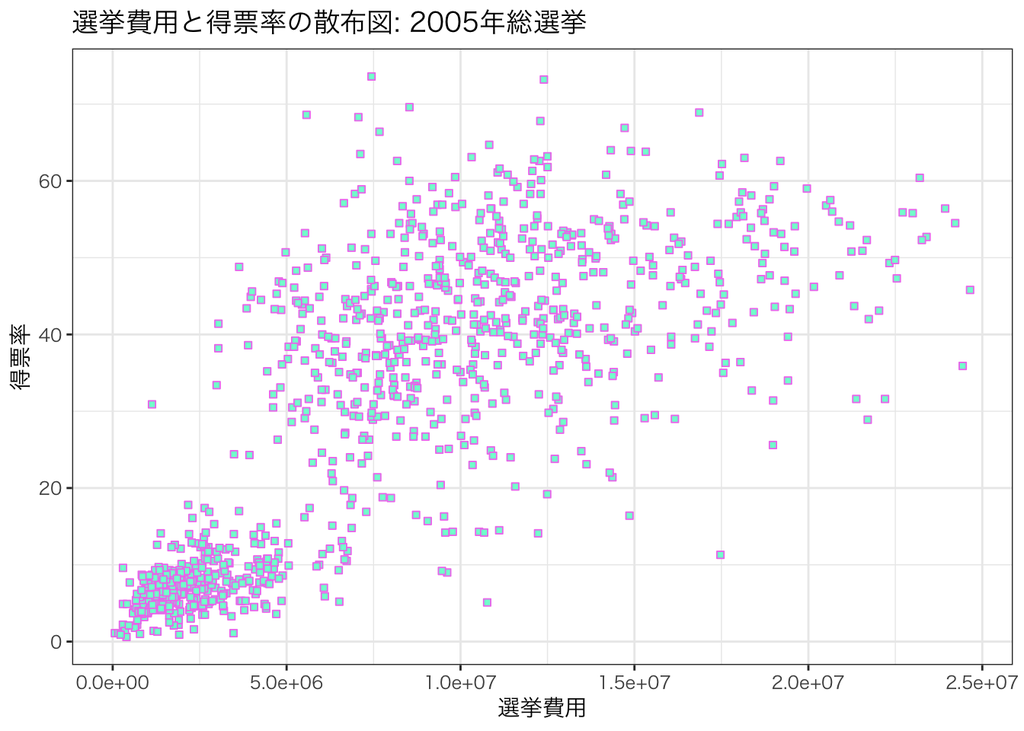

```r
df05 %>%
   ggplot() +
   geom_point(aes(x = exp,
                  y = voteshare),
              color = "violet",    # 枠線の色を指定
              fill = "aquamarine",　# 内側の色塗り指定
              shape = 22) +     # ドットの形を指定
   labs(x = "選挙費用",
        y = "得票率") +
  ggtitle("選挙費用と得票率の散布図: 2005年総選挙") +
  theme_bw(base_family = "HiraKakuProN-W3")
```

# 2. 次元の追加

- 前節で作った散布図は`exp` と `votehsare` という 2 つの情報 (= 2 次元) をもつ
- 散布図は情報の数（＝次元）を拡大できる
- ここでは `if_else()` 関数を使って自民党ダミー `ldp` を作成し、散布図に次元を追加してみる
- `aes()` 関数の内側に `shape = ldp` と指定してみる

## 2.1 ドットの「形」を変えて次元追加

- `aes()` の内側に `shape = ldp` と指定  
  → 自民党候補者か否かでドットの形を変えることができる
- 2行目の `mutate(ldp = if_else(seito == "自民", "自民党", "非自民党"))`の意味  
  → `seito` の値が「自民」なら「自民党」、それ以外なら「非自民党」と指定した新たな変数 `ldp` を作成する

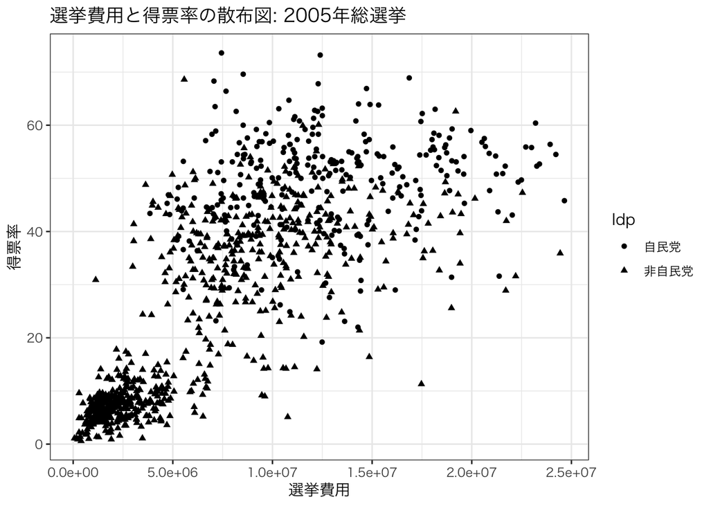

```r
df05 %>%
  mutate(ldp = if_else(seito == "自民", "自民党", "非自民党")) %>%
   ggplot() +
   geom_point(aes(x = exp,
                  y = voteshare,
                  shape = ldp)) +　# ldp をドットの形で区別
   labs(x = "選挙費用",
        y = "得票率") +
  ggtitle("選挙費用と得票率の散布図: 2005年総選挙") +
  theme_bw(base_family = "HiraKakuProN-W3")
```

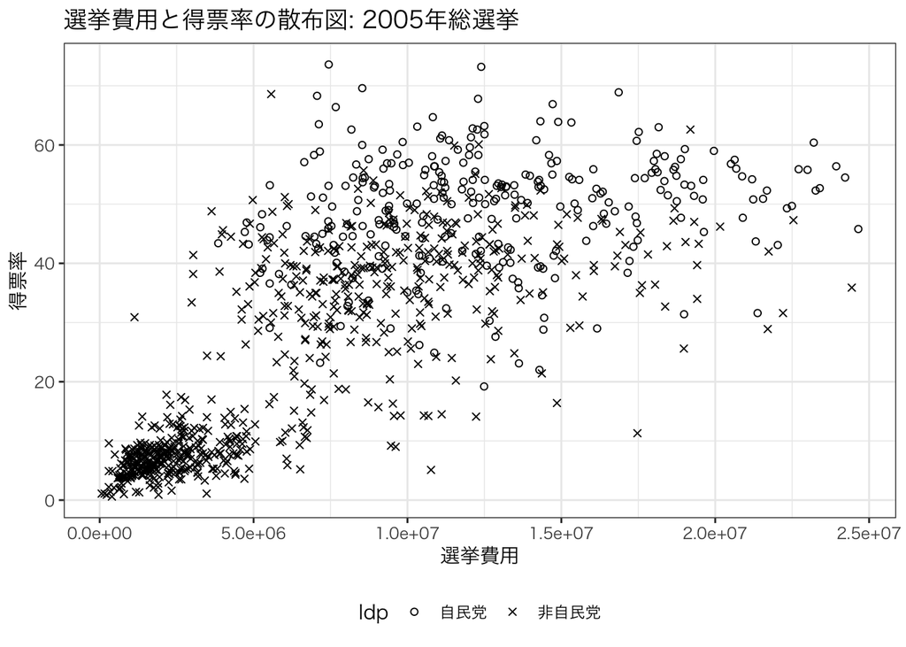

```r
df05 %>%
  mutate(ldp = if_else(seito == "自民", "自民党", "非自民党")) %>%
   ggplot() +
   geom_point(aes(x = exp,
                  y = voteshare,
                  shape = ldp)) +　# ldp をドットの形で区別
   labs(x = "選挙費用",
        y = "得票率") +
  ggtitle("選挙費用と得票率の散布図: 2005年総選挙") +
  theme_bw(base_family = "HiraKakuProN-W3")  +
  theme(legend.position = "bottom") + # レジェンドの位置を下に
  scale_shape_manual(values = c("自民党" = 1,    # 「○」は 1
                                "非自民党" = 4))  # 「×」は 4
```

- 「`●`」と「`▲`」よりずっと見やすくなった

## 2.2 ドットの色を変えて次元追加

- 全体に占める自民党候補者の傾向をさらに見やすくするためには  
  → 色分けして表示してみる
- `aes()` 関数の内側に `color = ldp` と指定してみる

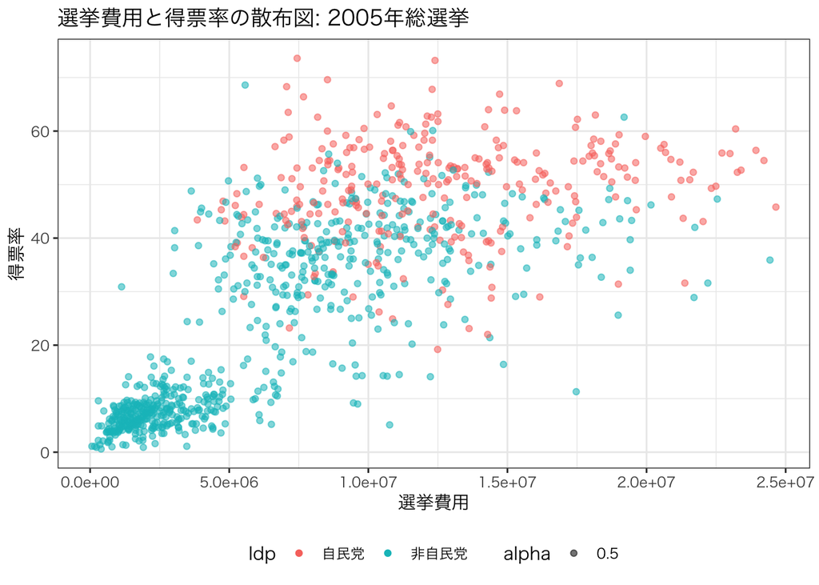

```r
df05 %>%
  mutate(ldp = if_else(seito == "自民", "自民党", "非自民党")) %>%
   ggplot() +
   geom_point(aes(x = exp,
                  y = voteshare,
                  color = ldp,    # ldp を色分け
                  alpha = 0.5)) + # 透明度を追加
   labs(x = "選挙費用",
        y = "得票率") +
  ggtitle("選挙費用と得票率の散布図: 2005年総選挙") +
  theme_bw(base_family = "HiraKakuProN-W3") +
  theme(legend.position = "bottom") # レジェンドの位置を下に
```

- 「小泉劇場」と呼ばれた2005年の小泉郵政選挙では、自民党候補者の方がより多く得票している傾向がよく分かる

## 2.3 ドットの色を指定する

- ドットを好みの色に指定したい場合
- `scale_color_manual()` レイヤーを追加
- 引数は `values`
- `c("値1" = "色1", "値2" = "色2", ...)` のように名前を付け  
  → `character` 型ベクトルを指定

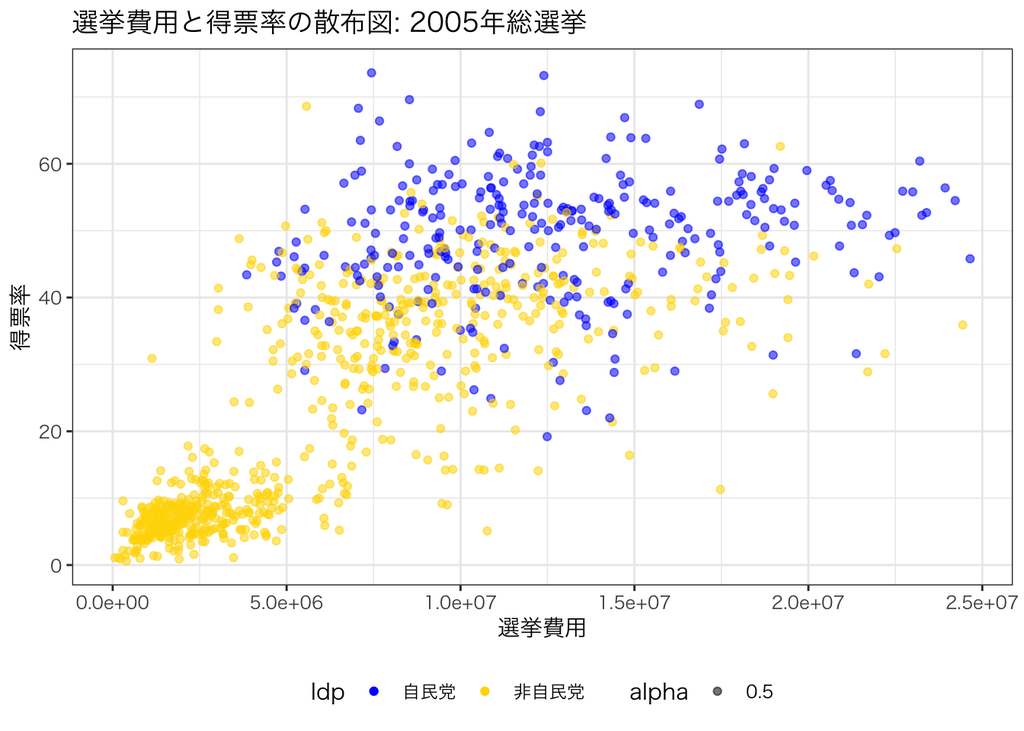

```r
df05 %>%
  mutate(ldp = if_else(seito == "自民", "自民党", "非自民党")) %>%
   ggplot() +
   geom_point(aes(x = exp,
                  y = voteshare,
                  color = ldp,    # ldp を色分け
                  alpha = 0.5)) + # 透明度を追加
   labs(x = "選挙費用",
        y = "得票率") +
  ggtitle("選挙費用と得票率の散布図: 2005年総選挙") +
  theme_bw(base_family = "HiraKakuProN-W3") +
  theme(legend.position = "bottom") + # レジェンドの位置を下に
  scale_color_manual(values = c("自民党" = "blue",
                                "非自民党" = "gold"))
```

- 2005年の小泉郵政選挙では、自民党候補者の方がより多く得票している傾向がよく分かる
- `ggplot2` で使える色は **657 種類!**
- `"red"`、`"skyblue"`、`"royalblue"`のように文字で指定できる
- Rで使用可能な色のリストはコンソール上で `colors()` と打ち込むと確認できる
- ここでは最初の 6 色を示す

```r
head(colors())
```

```
[1] "white"         "aliceblue"     "antiquewhite"  "antiquewhite1"
[5] "antiquewhite2" "antiquewhite3"
```

- これ以外にも `RGB`カラー（HEmathコード; 16進数）で指定することもできる
- たとえば赤なら `"#FF0000"`、ロイヤルブルーなら `"#4169E1"`と表記
- HEmathコードを使う場合 → 非常に細かく色を指定可能  
  → **16,777,216 種類!!!** の色が使える
- 以下の例は R で使える色の一部

[figure not shown]

Source:https://blog.albertkuo.me/post/point-shape-options-in-ggplot/

# 3. 回帰直線を加えた散布図 (1)

- 2005年総選挙における「選挙費用」と「得票率」の散布図に回帰直線を加えてみる

### シンプルな散布図に回帰直線を加えたい場合

- `ggplot()` の内側に `aes()` 関数を指定する  
  → `geom_smooth(method = "lm", se = TRUE)` を追加する

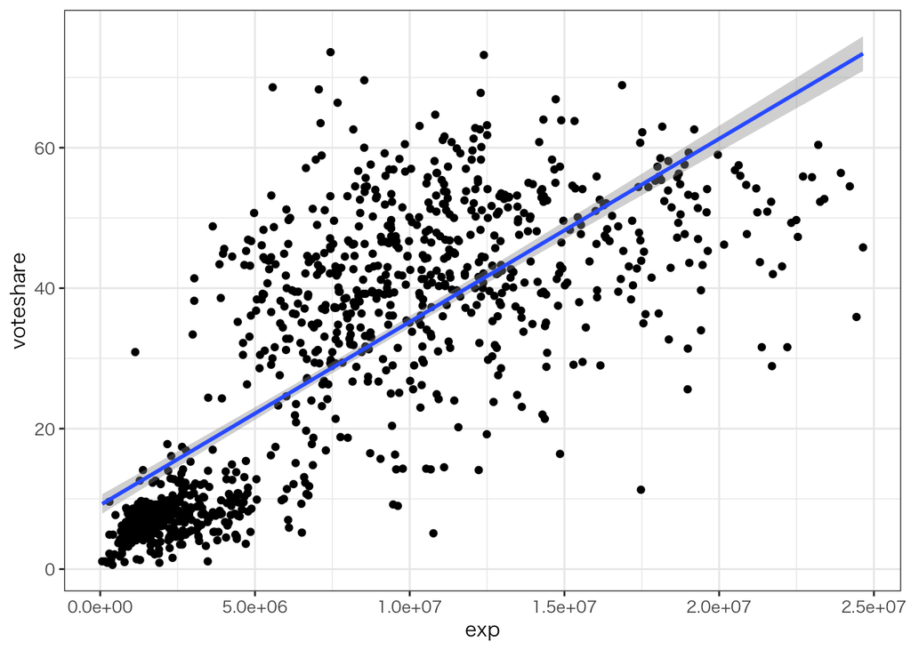

```r
df05 %>%
  ggplot(aes(x = exp,
             y = voteshare)) +
  geom_point() +
  geom_smooth(method = "lm", se = TRUE) +
  theme_bw(base_family = "HiraKakuProN-W3")
```

### 自民党と非自民党ごとに回帰直線を加えたい場合

- `ggplot()` の内側に `aes()` 関数を指定し、そこに `x` 軸、`y` 軸、`color` の設定をする
- `color = ldp` の指定
- `geom_smooth(method = "lm", se = TRUE)` の指定

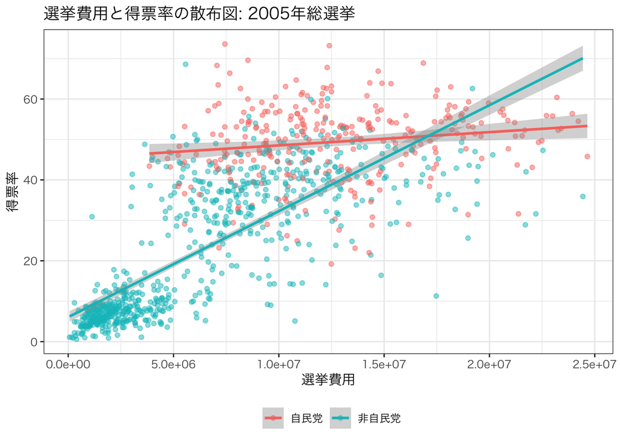

```r
df05 %>%
  mutate(ldp = if_else(seito == "自民", "自民党", "非自民党")) %>%
  ggplot(aes(x = exp,
             y = voteshare,
             color = ldp)) + # 自民党と非自民党ごとに回帰直線を引く
  geom_point(alpha = 0.5) +
  geom_smooth(method = "lm",
              se = TRUE) + # 自民党と非自民党ごとに回帰直線を引く
  labs(x = "選挙費用",
       y = "得票率",
       color = "") +
  ggtitle("選挙費用と得票率の散布図: 2005年総選挙") +
  theme_bw(base_family = "HiraKakuProN-W3") +
  theme(legend.position = "bottom")
```

### 政党ごとに回帰直線を加えたい場合

- `ggplot()` の内側に `aes()` 関数を指定し、そこに `x` 軸、`y` 軸、`color` の設定をする
- `color = seito` の指定
- `geom_smooth(method = "lm", se = TRUE)` の指定

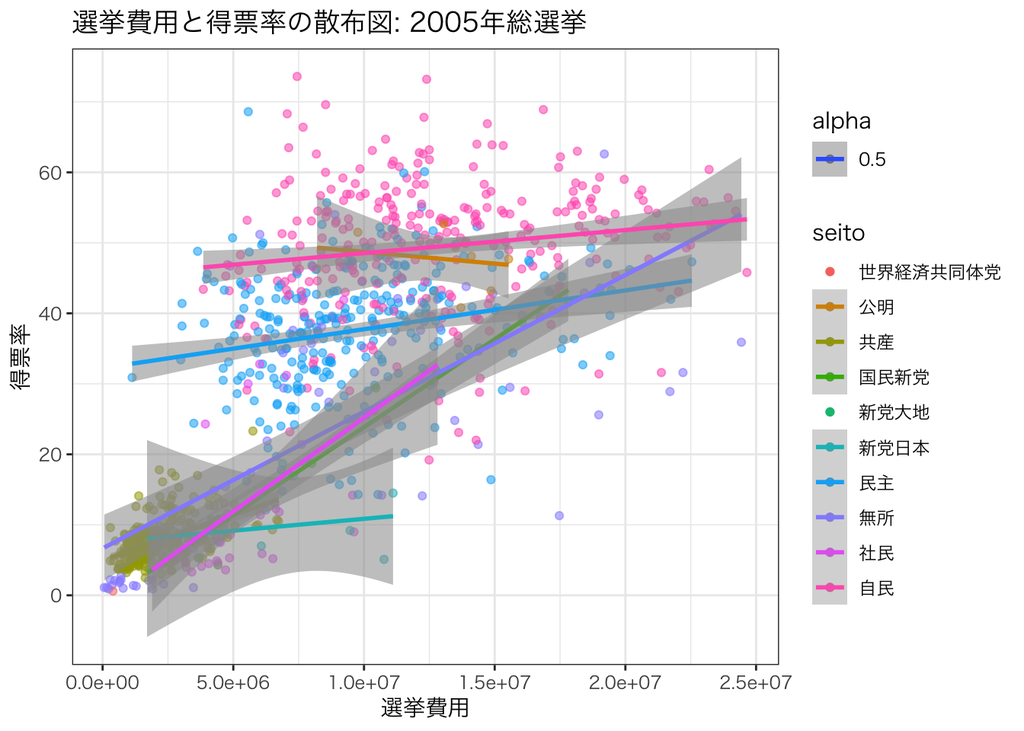

```r
plot_vs_05 <- df05 %>%
   ggplot(aes(x = exp,
              y = voteshare,
              color = seito,
              alpha = 0.5)) + # ドットの透明度を指定
   geom_point() +
  geom_smooth(method = lm, se = TRUE) + 　　# 回帰直線を引く
   labs(x = "選挙費用",
        y = "得票率") +
  ggtitle("選挙費用と得票率の散布図: 2005年総選挙") +
  theme_bw(base_family = "HiraKakuProN-W3")

plot_vs_05
```

- `facet_wrap()` 関数を使って、政党ごとに見やすく表示してみる

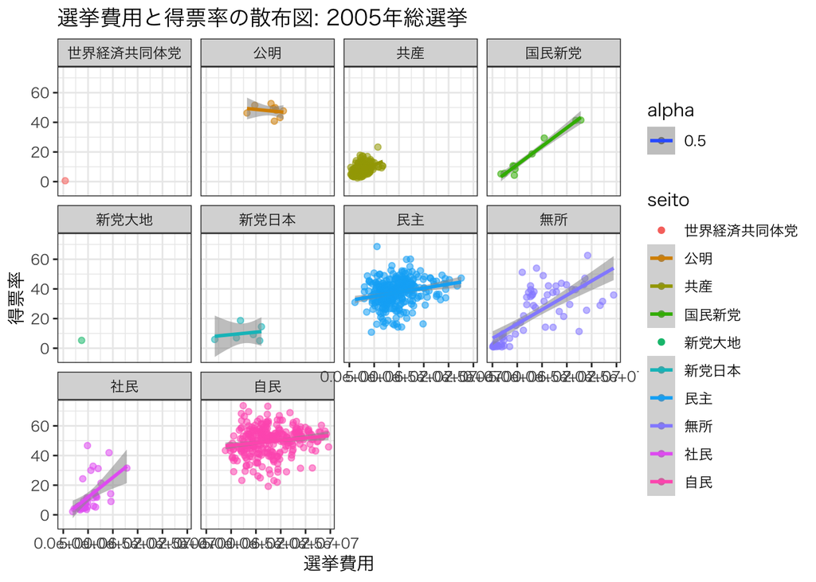

```r
plot_vs_05 +
  facet_wrap(~seito)    # 政党ごとに facet する
```

- `x` 軸のラベルが長く、左右でオーバーラップしている  
  → `x` 軸のラベルを 40度回転させてみる
- `theme()` レイヤーを追加し、`axis.text.x` を指定

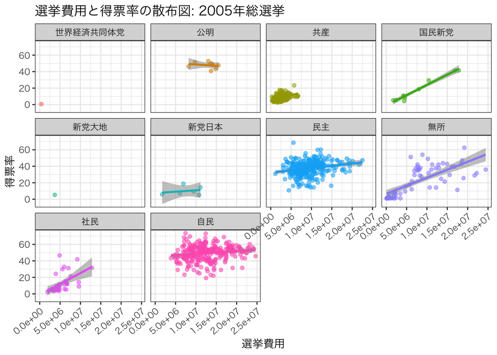

```r
plot_vs_05 +
  facet_wrap(~seito)  +  # 政党ごとに facet する
  theme(legend.position = "none") + # レジェンドを非表示
  theme(axis.text.x  = element_text(angle = 40, vjust = 1, hjust = 1)) # 35度回転
```

- 2005年の総選挙は小泉郵政選挙と呼ばれる
- 自民党と民主党を比較したい
- しかし、自民党と民主党の図は隣同士ではない
- `ggplot()`に渡す前に `seito` を `factor` 化して、順番を変える

```r
unique(df05$seito)
```

```
 [1] "社民"             "共産"             "自民"             "民主"
 [5] "無所"             "新党日本"         "国民新党"         "新党大地"
 [9] "公明"             "世界経済共同体党"
```

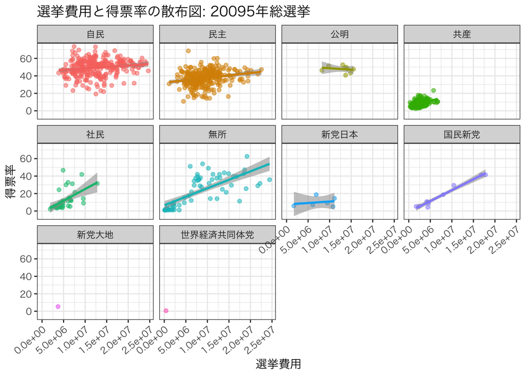

```r
df05 %>%
   mutate(seito = factor(seito,
                         levels = c("自民", "民主", "公明", "共産", "社民",
                           "無所", "新党日本", "国民新党", "新党大地",
                           "世界経済共同体党"))) %>%
   ggplot(aes(x = exp,
              y = voteshare,
              color = seito,
              alpha = 0.5)) + # ドットの透明度を指定
   geom_point() +
  geom_smooth(method = lm) + 　　# 回帰直線を引く
   labs(x = "選挙費用",
        y = "得票率") +
  ggtitle("選挙費用と得票率の散布図: 20095年総選挙") +
  theme_bw(base_family = "HiraKakuProN-W3") +
  facet_wrap(~seito, ncol = 4) + # 4 列表示にする
  theme(legend.position = "none") + # レジェンドを非表示
  theme(axis.text.x  = element_text(angle = 40, vjust = 1, hjust = 1)) # 35度回転
```

##### 視覚的に確認できること

- 民主党候補者より自民党候補者の方が多く得票している
- 自民党候補者は選挙費用を使わなくても使っても、得票に影響しない（傾きがほぼフラット）
- 民主党候補者は、自民党候補者よりも、選挙費用の得票への影響がほんの少しだけ大きい（傾きがわずかだけ大きい）
- 無所属、社民、国民新党の候補者は、選挙費用が得票に大きく影響する（傾きが大きい）

##### 政党別の得票率を計算してみる

- `group_by()` 関数を使って、政党ごとの得票率を計算する

```r
df05_vs_ave <- df05 %>%
  group_by(seito) %>%
  summarise(ave_vs = mean(voteshare,
                          na.rm = TRUE))
```

```r
datatable(df05_vs_ave) %>%
  formatRound(columns = "ave_vs", digits = 2)　# 小数点2位まで表示
```

|  | seito | ave_vs |
| --- | --- | --- |
| 1 | 世界経済共同体党 | 0.6 |
| 2 | 公明 | 47.73333333333333 |
| 3 | 共産 | 7.794545454545454 |
| 4 | 国民新党 | 17.56 |
| 5 | 新党大地 | 5.3 |
| 6 | 新党日本 | 10.06666666666667 |
| 7 | 民主 | 37.51107266435986 |
| 8 | 無所 | 21.82142857142857 |
| 9 | 社民 | 12.72631578947368 |
| 10 | 自民 | 49.42275862068966 |

- 自民党候補者（49.4%）、公明党候補者（47.7%）の政権与党の得票率がかなりそれぞれ50%に近い
- 民主党候補者の得票率は 37.5%

##### 政党別の選挙費用を計算してみる

- `group_by()` 関数を使って、平均選挙費用を政党ごとに計算する

```r
df05_exp_ave <- df05 %>%
  group_by(seito) %>%
  summarise(ave_exp = mean(exp,
                          na.rm = TRUE))
```

```r
datatable(df05_exp_ave) %>%
  formatRound(columns = "ave_exp", digits = 0)　# 小数点以下を表示しない
```

|  | seito | ave_exp |
| --- | --- | --- |
| 1 | 世界経済共同体党 | 395805 |
| 2 | 公明 | 12955601.66666667 |
| 3 | 共産 | 2200499.927272727 |
| 4 | 国民新党 | 7477416.1 |
| 5 | 新党大地 | 3701570 |
| 6 | 新党日本 | 7666787.5 |
| 7 | 民主 | 9574472.955017302 |
| 8 | 無所 | 7927537.223880597 |
| 9 | 社民 | 5318982.578947368 |
| 10 | 自民 | 12710074.72318339 |

- 公明党の候補者が最も多くの選挙費用（平均:約1296万円）を使っている

# 4. 回帰直線を加えた散布図 (2)

- 「GDP」と「寿命」の散布図
- ここでは R が備えている `{gapminder}` というデータを使って、 2 次元平面で表現できる散布図に、もう一つ次元を加えて 3 次元以上の情報を可視化する方法を紹介する
- `{gapminder}` パッケージをダウンロードする

```r
library(gapminder)
```

- [`{gapminder}`](https://cran.r-project.org/web/packages/gapminder/README.html) には次の変数が含まれている

| 変数名 | 詳細 |
| --- | --- |
| country | 国名 |
| continent | 大陸名 |
| year | 年 |
| lifeExp | 寿命 |
| pop | 人口 |
| gdpPercap | 一人あたり GDP, 2005年の時点での米ドルで表示 |

- 記述統計を示す

```r
library(stargazer)
```

- チャンクオプションで `{r, results = "asis"}` と指定する

```r
stargazer(as.data.frame(gapminder),
          type ="html",
          digits = 2)
```

| Statistic | N | Mean | St. Dev. | Min | Max |
| --- | --- | --- | --- | --- | --- |
| year | 1,704 | 1,979.50 | 17.27 | 1,952 | 2,007 |
| lifeExp | 1,704 | 59.47 | 12.92 | 23.60 | 82.60 |
| pop | 1,704 | 29,601,212.00 | 106,157,897.00 | 60,011 | 1,318,683,096 |
| gdpPercap | 1,704 | 7,215.33 | 9,857.45 | 241.17 | 113,523.10 |

```r
DT::datatable(gapminder)
```

|  | country | continent | year | lifeExp | pop | gdpPercap |
| --- | --- | --- | --- | --- | --- | --- |
| 1 | Afghanistan | Asia | 1952 | 28.801 | 8425333 | 779.4453145 |
| 2 | Afghanistan | Asia | 1957 | 30.332 | 9240934 | 820.8530296 |
| 3 | Afghanistan | Asia | 1962 | 31.997 | 10267083 | 853.10071 |
| 4 | Afghanistan | Asia | 1967 | 34.02 | 11537966 | 836.1971382 |
| 5 | Afghanistan | Asia | 1972 | 36.088 | 13079460 | 739.9811058 |
| 6 | Afghanistan | Asia | 1977 | 38.438 | 14880372 | 786.11336 |
| 7 | Afghanistan | Asia | 1982 | 39.854 | 12881816 | 978.0114388 |
| 8 | Afghanistan | Asia | 1987 | 40.822 | 13867957 | 852.3959448 |
| 9 | Afghanistan | Asia | 1992 | 41.674 | 16317921 | 649.3413952 |
| 10 | Afghanistan | Asia | 1997 | 41.763 | 22227415 | 635.341351 |

[output cut: 1694 more lines]

## 4.1 シンプルな散布図 (`{gapminder}`)

- まず、「一人あたり GDP (`gdpPercap`)」を `x` 軸、「平均寿命 (`lifeExp`)」を `y` 軸に指定して散布図を描いてみる
- `ggplot()` に渡す前に、人口を「百万人単位に換算した」変数 `pop_m` を作成する

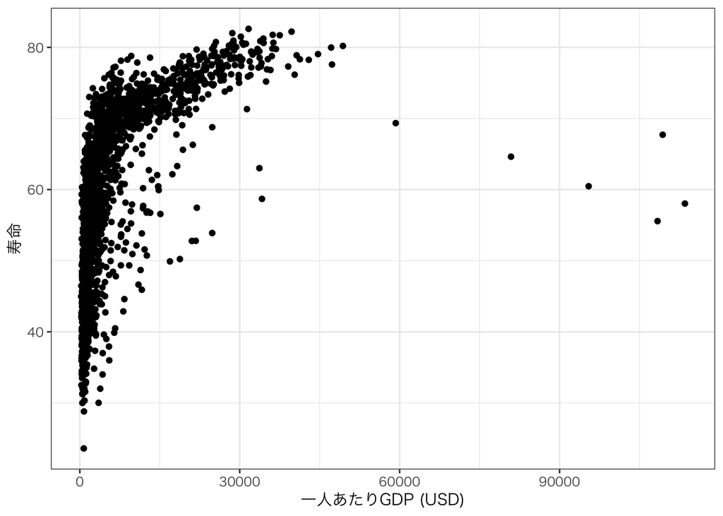

```r
gapminder %>%
  mutate(pop_m = pop / 1000000) %>%  #人口を百万人単位に換算した変数 pop_mを作成
  ggplot() +
  geom_point(aes(x = gdpPercap,
                 y = lifeExp)) +
  labs(x = "一人あたりGDP (USD)",
       y = "寿命") +
  theme_bw(base_family = "HiraKakuProN-W3")
```

- 「一人あたり `GDP`」の記述統計を見ると、データの範囲が 241米ドル（最低額）から 113,523 米ドル（最高額）まで非常に広範囲に及ぶ
- 「一人あたり GDP」と「平均寿命」はリニアというより、対数関係のような関係  
  → 見やすくするため、`x` 軸を `log 変換` する
- `x = log(gdpPercap)` と指定

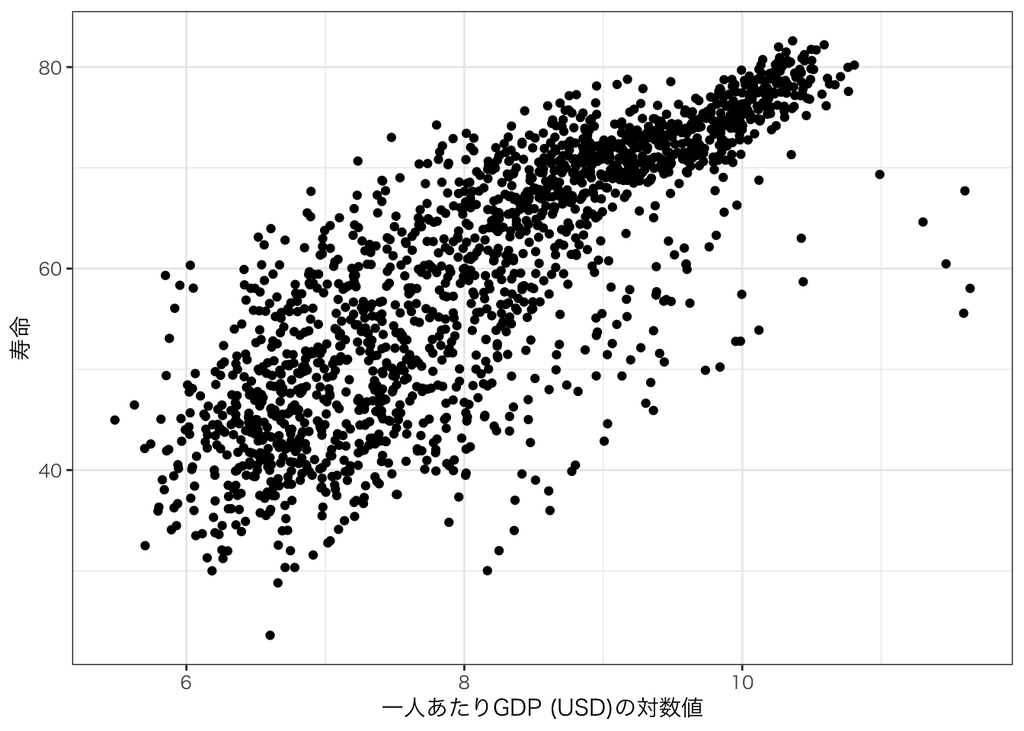

```r
gapminder %>%
  mutate(pop_m = pop / 1000000) %>%
  ggplot() +
  geom_point(aes(x = log(gdpPercap), # gdpPercap を log 変換
                 y = lifeExp)) +
  labs(x = "一人あたりGDP (USD)の対数値",
       y = "寿命") +
  theme_bw(base_family = "HiraKakuProN-W3")
```

- `gdpPercap` を対数化したら、かなり綺麗な線形関係が確認できた
- ちなみに、画面の右端にある「一人あたり GDP」 が抜きん出て高い超リッチ国を確かめてみる

```r
gapminder %>%
  dplyr::filter(gdpPercap > 60000) %>%
  dplyr::select(year, country, gdpPercap)
```

```
# A tibble: 5 × 3
   year country gdpPercap
  <int> <fct>       <dbl>
1  1952 Kuwait    108382.
2  1957 Kuwait    113523.
3  1962 Kuwait     95458.
4  1967 Kuwait     80895.
5  1972 Kuwait    109348.
```

## 4.2 大陸と人口を散布図に追加

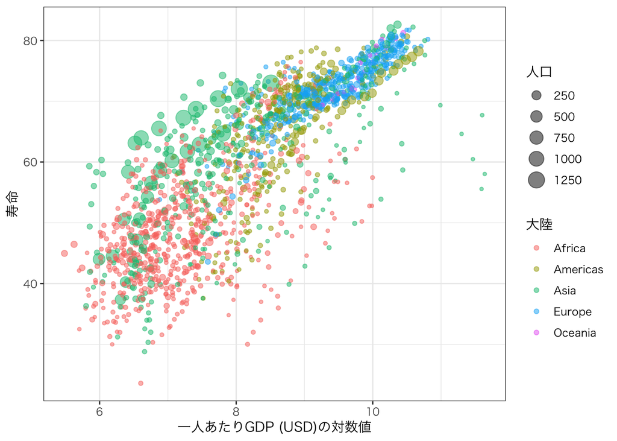

```r
gapminder %>%
  mutate(pop_m = pop / 1000000) %>%
  ggplot() +
  geom_point(aes(x = log(gdpPercap),
                 y = lifeExp,
                 color = continent,
                 size = pop_m),
             alpha = 0.5) +
  labs(x = "一人あたりGDP (USD)の対数値",
       y = "寿命",
       size = "人口",
       color = "大陸") +
  theme_bw(base_family = "HiraKakuProN-W3")
```

## 4.3 リニアな線を引いてみる

- `geom_smooth(method = lm)` と指定してリニアな線を引いてみる

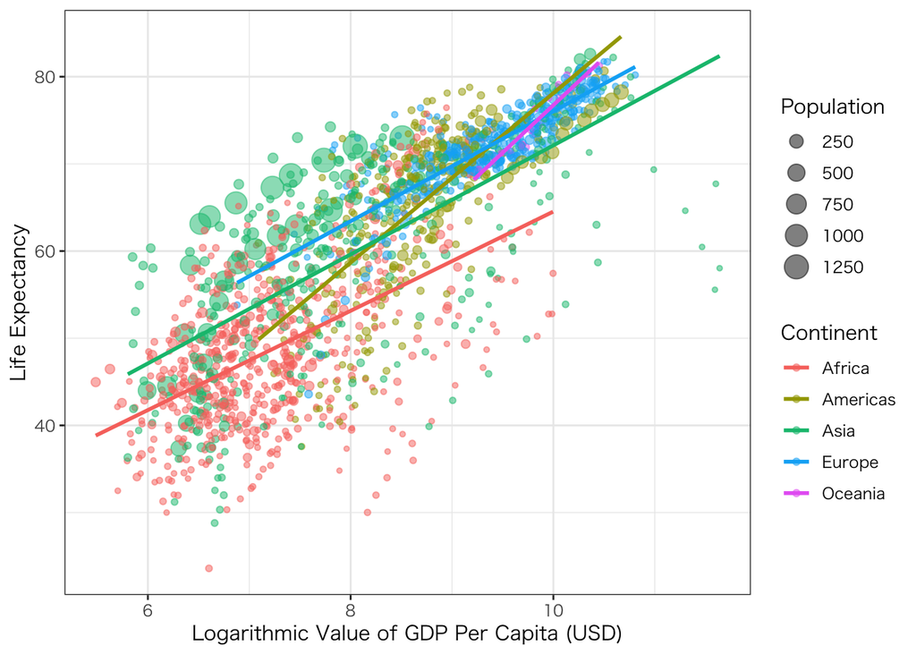

```r
gapminder %>%
  mutate(pop_m = pop / 1000000) %>%
  ggplot() +
  geom_point(aes(x = log(gdpPercap),
                 y = lifeExp,
                 color = continent,
                 size = pop_m),
             alpha = 0.5) +

  geom_smooth(aes(
      x = log(gdpPercap),
      y = lifeExp,
      color = continent),
    method = "lm",
    se = FALSE) +

  labs(x = "Logarithmic Value of GDP Per Capita (USD)",
       y = "Life Expectancy",
       size = "Population",
       color = "Continent") +
  theme_bw(base_family = "HiraKakuProN-W3")
```

## 4.4 次元ごとに分類して表示

- `facet_wrap(~continent)` を指定して、大陸ごとに散布図を別々に描く

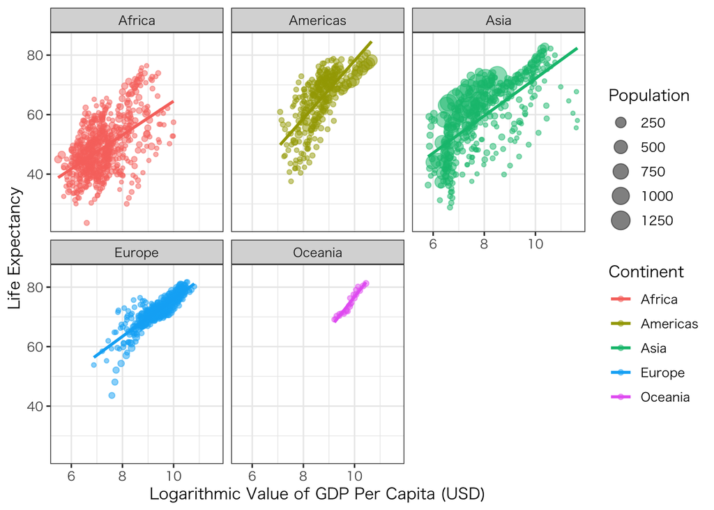

```r
gapminder %>%
  mutate(pop_m = pop / 1000000) %>%
  ggplot() +
  geom_point(aes(x = log(gdpPercap),
                 y = lifeExp,
                 color = continent,
                 size = pop_m),
             alpha = 0.5) +

  geom_smooth(aes(
      x = log(gdpPercap),
      y = lifeExp,
      color = continent),
    method = "lm",
    se = FALSE) +

  labs(x = "Logarithmic Value of GDP Per Capita (USD)",
       y = "Life Expectancy",
       size = "Population",
       color = "Continent") +
  theme_bw(base_family = "HiraKakuProN-W3") +
  facet_wrap(~continent)
```

## 4.5 特定の国をハイライトして表示

- 日本、アメリカ、中国のデータを特定してみる
- `{gghighlight}` パッケージを使う

```r
library(gghighlight)
```

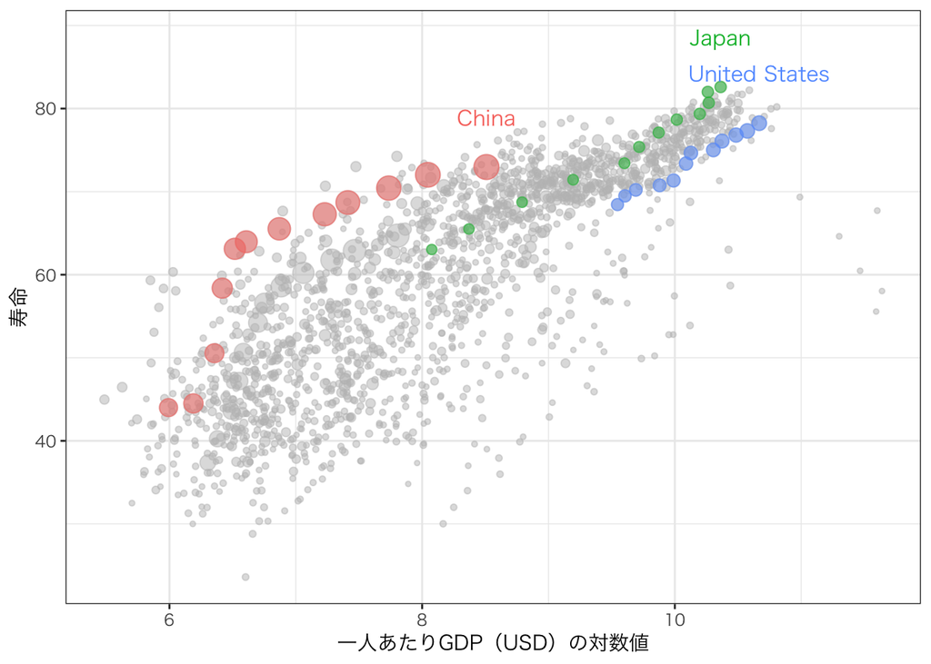

```r
gapminder %>%
  mutate(pop_m = pop / 1000000) %>%
  ggplot(aes(
      x = log(gdpPercap),
      y = lifeExp,
      color = country,
      size = pop_m)) +
  geom_point(alpha = 0.5) +
  gghighlight(
    country %in% c("Japan", "China", "United States")) +
  geom_text(data = gapminder %>%
      filter(year == 2007,
        country %in% c("Japan", "China", "United States")),
    aes(label = country),
    nudge_y = 6,
    size = 4,
    show.legend = FALSE) +
  labs(x = "一人あたりGDP（USD）の対数値",
    y = "寿命",
    size = "人口",
    color = "国") +
  guides(size = "none",color = "none") +
  theme_bw(base_family = "HiraKakuProN-W3")
```

# 5. 散布図に文字を表示させる

## 5.1 データの準備

- ここでは 18 歳有権者と投票率データを使って散布図を考える
- 第24回 (2016) 参議院議員選挙データ [`vote_18.csv`](https://asanoucla.github.io/vote_18.csv) をダウンロード → `RProject`フォルダに保存
- データを読み込む

```r
hc2016 <- read_csv("data/vote_18.csv")
```

- 変数の詳細は次のとおり

| 変数名 | 詳細 |
| --- | --- |
| pref | 都道府県 |
| age18 | 18歳有権者の投票率 |
| age19 | 19歳有権者の投票率 |
| age1819 | 18歳と19際有権者の投票率 |
| all | 都道府県の投票率 |
| did | 都道府県の人口密度 |

- データの記述統計を示す

**注意：チャンク・オプションには`{r, results = "asis"`と入力すること**

```r
stargazer(data.frame(hc2016),
          type = "html")
```

| Statistic | N | Mean | St. Dev. | Min | Max |
| --- | --- | --- | --- | --- | --- |
| serial | 47 | 24.000 | 13.711 | 1 | 47 |
| age18 | 47 | 48.389 | 5.307 | 35.290 | 62.230 |
| age19 | 47 | 38.419 | 6.033 | 26.580 | 53.800 |
| age1819 | 47 | 43.446 | 5.558 | 30.930 | 57.840 |
| all | 47 | 54.968 | 3.887 | 45.520 | 62.860 |
| did | 47 | 655.374 | 1,194.258 | 68.650 | 6,168.040 |

- {DT}パッケージを使って、インターアクティブなデータの記述統計を表示する

```r
DT::datatable(hc2016)
```

|  | serial | pref | age18 | age19 | age1819 | all | did |
| --- | --- | --- | --- | --- | --- | --- | --- |
| 1 | 3 | 愛知 | 58.2 | 49.4 | 53.77 | 55.41 | 1446.91 |
| 2 | 45 | 愛媛 | 41.43 | 29.9 | 35.78 | 56.36 | 244.15 |
| 3 | 23 | 茨城 | 47.73 | 37.93 | 42.85 | 50.77 | 478.57 |
| 4 | 35 | 岡山 | 45.34 | 33.74 | 39.53 | 50.86 | 270.18 |
| 5 | 25 | 沖縄 | 46.07 | 38.99 | 42.58 | 54.46 | 628.7 |
| 6 | 21 | 岩手 | 47.97 | 37.74 | 43.03 | 57.78 | 83.78 |
| 7 | 9 | 岐阜 | 52.9 | 45.05 | 49.01 | 57.74 | 191.36 |
| 8 | 46 | 宮崎 | 38.54 | 28.07 | 33.61 | 49.76 | 142.77 |
| 9 | 14 | 宮城 | 49.99 | 41.39 | 45.65 | 52.39 | 320.54 |
| 10 | 11 | 京都 | 51.12 | 42.78 | 46.86 | 51.16 | 565.92 |

[output cut: 37 more lines]

- 参考：画面に全てのデータフレームを一気に表示させるだけなら **`knitr::kable(hr2005)`** というコマンドを入力

データの出典：

- [第24回参議院議員通常選挙における18歳と19歳の投票率のデータ](https://uub.jp/pdr/p/young.html):  
  総務省 2016年（平成28年）7月10日実施
- 人口密度データ (`did`) の出典は[こちら](https://uub.jp/rnk/rnk.cgi?T=p&S=j&B=20160401): 2016年4月1日の時点のデータ

## 5.2 次元を加えた散布図（都道府県）

### 5.2.1 散布図を見やすくする方法

**「都市度」と「全有権者の投票率」**

- 「都市度」と「全有権者の投票率」の散布図に次元（都道府県名）を加えてみる
- 「都市度 (`did`)」を x 軸、「全有権者の投票率 (`all`)」を y 軸に指定して散布図を描く
- `geom_text()` 関数を使って、都道府県を表示させる

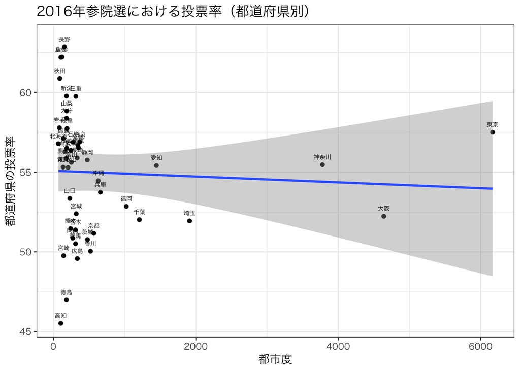

```r
hc2016 %>%
  ggplot(aes(did, all)) +
  geom_point() +
  stat_smooth(method = lm) +
  geom_text(aes(y = all + 0.5,
                label = pref),
            size = 2,
            family = "HiraKakuPro-W3") +
  labs(x = "都市度", y = "都道府県の投票率") +
  ggtitle("2016年参院選における投票率（都道府県別）") +
  theme_bw(base_family = "HiraKakuProN-W3")
```

**「都市度 」と「18歳の投票率」の散布図**

- 「都市度 (`did`)」を x 軸、「18歳の投票率 (`age18`)」を y 軸に指定して散布図を描く
- `geom_text()` 関数を使って、都道府県を表示させる

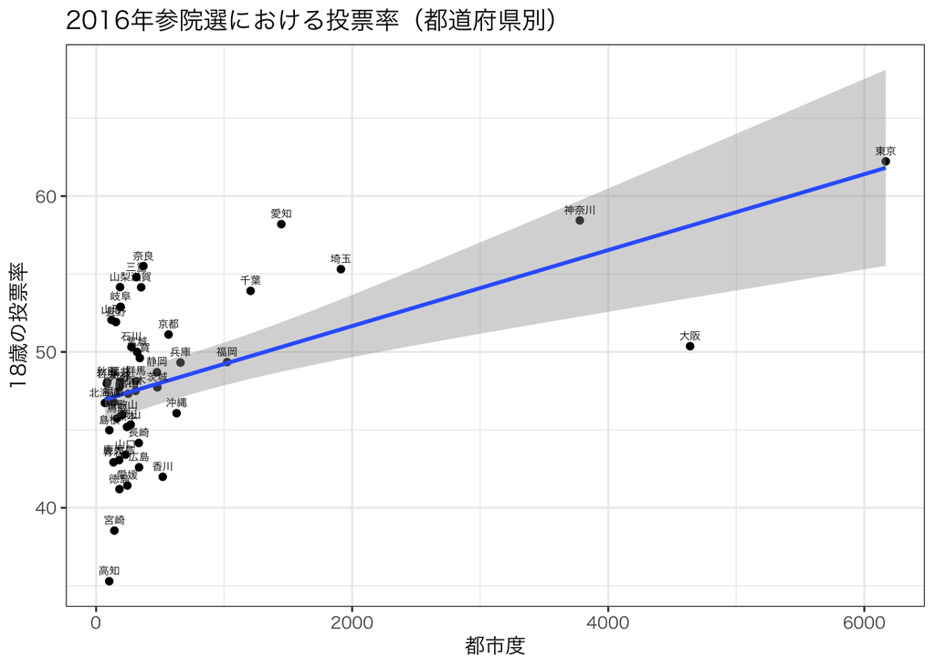

```r
hc2016 %>%
  ggplot(aes(did, age18)) +
  geom_point() +
  stat_smooth(method = lm) +
  geom_text(aes(y = age18 + 0.7,
                label = pref),
            size = 2,
            family = "HiraKakuPro-W3") +
  labs(x = "都市度", y = "18歳の投票率") +
  ggtitle("2016年参院選における投票率（都道府県別）") +
  theme_bw(base_family = "HiraKakuProN-W3")
```

- 都道府県の文字が重なり判別しにくい
- 人口密度が高いトップ 3 である東京、大阪、神奈川が「外れ値」として右側に孤立している  
  → グラフが見にくい

**解決策：**  
(1) 外れ値（この場合だと、東京、大阪、神奈川）をデータに含めない  
(2) 値の差が大きい変数（この場合だと、都市度 `did`）を対数変換する

- それぞれ試してみる

##### (1) 特定の「外れ値」を省いた散布図

- 人口密度が高いトップ 3 である東京、大阪、神奈川をデータから外して散布図を描いてみる
- この 3 つの都道府県の「都市度」は目視で 2000 以上だとわかる  
  → `dplyr::filter(did < 2000)` と指定

#### `{ggrepel}`:

- `{ggrepel}` パッケージを使って都道府県名の表示を読みやすくばらつかせることができる

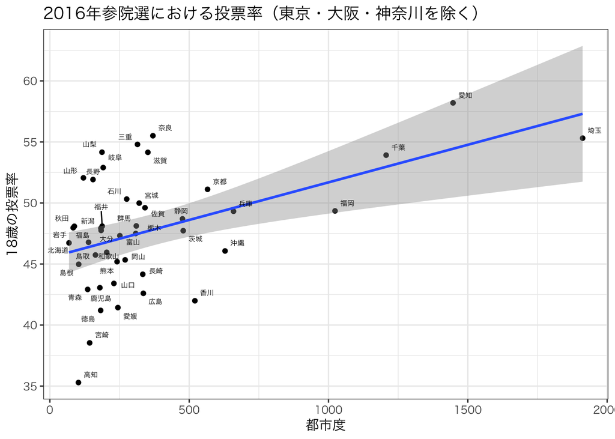

```r
hc2016 %>%
  filter(did < 2000) %>% # 東京、大阪、神奈川を除外する設定
  ggplot(aes(did, age18)) +
  geom_point() +
  stat_smooth(method = lm) +
  ggrepel::geom_text_repel(aes(label = pref),
            size = 2,
            family = "HiraKakuPro-W3") +
  labs(x = "都市度", y = "18歳の投票率") +
  ggtitle("2016年参院選における投票率（東京・大阪・神奈川を除く）") +
  theme_bw(base_family = "HiraKakuProN-W3")
```

- だいぶ見やすくなった
- しかし、3つのケースを含めていないというマイナス面がある

##### (2)「都市度 (`did`)」 を対数変換した散布図

→ 見やすくするため、x 軸の「都市度 (`did`)」を `log 変換` する

- `x = log(did)` と指定

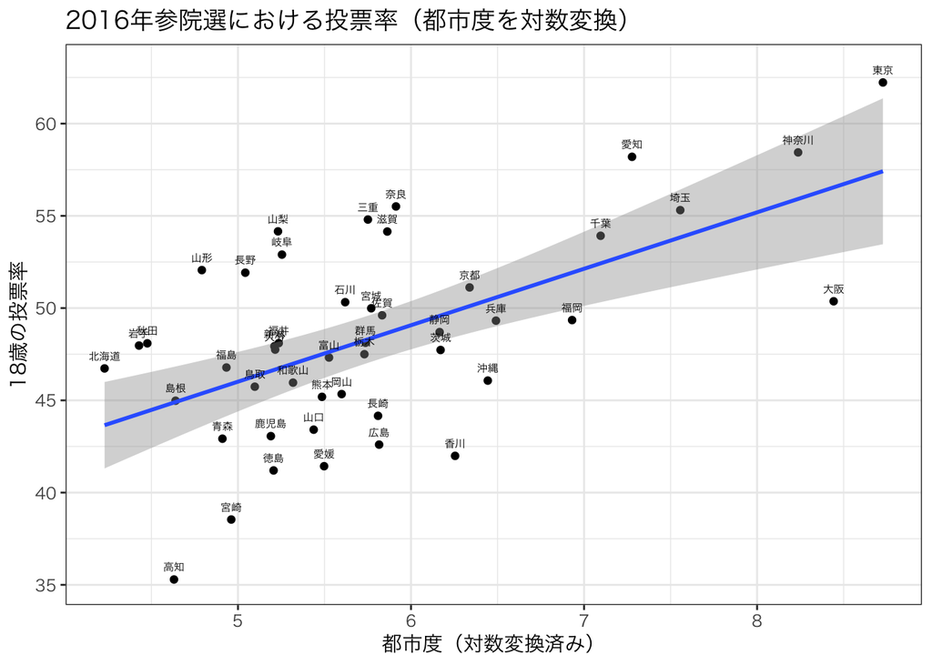

```r
hc2016 %>%
  ggplot(aes(log(did), age18)) +
  geom_point() +
  stat_smooth(method = lm) +
  geom_text(aes(y = age18 + 0.7,
                label = pref),
            size = 2,
            family = "HiraKakuPro-W3") +
  labs(x = "都市度（対数変換済み）", y = "18歳の投票率") +
  ggtitle("2016年参院選における投票率（都市度を対数変換）") +
  theme_bw(base_family = "HiraKakuProN-W3")
```

- だいぶ見やすくなった
- 全てのケースを含めているという利点がある
- しかし、回帰分析などをする場合、係数の解釈が単純ではないというマイナス面

#### 都道府県名を枠に入れる方法

- `geom_text_repel()`関数を使って、都道府県名を枠に入れる方法もある

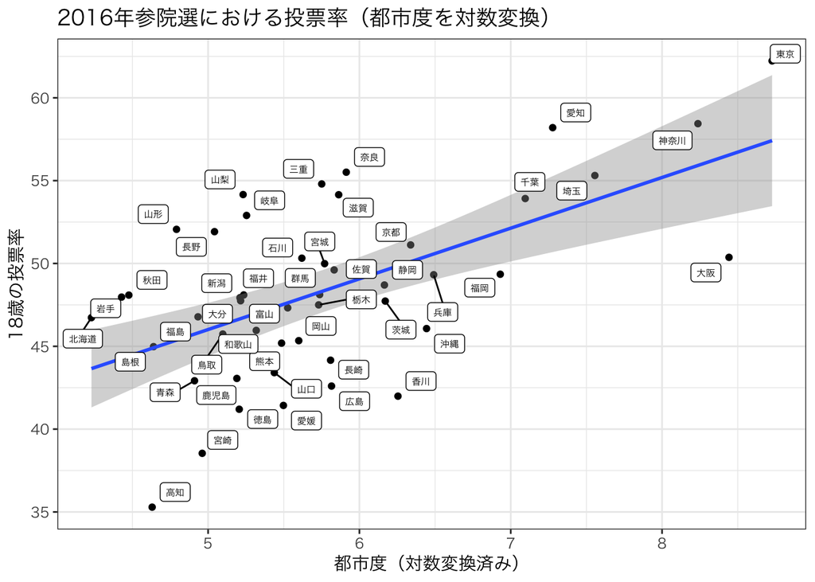

```r
hc2016 %>%
  ggplot(aes(log(did), age18)) +
  geom_point() +
  stat_smooth(method = lm) +
  ggrepel::geom_label_repel(aes(label = pref),
            size = 2,
            family = "HiraKakuPro-W3") +
  labs(x = "都市度（対数変換済み）", y = "18歳の投票率") +
  ggtitle("2016年参院選における投票率（都市度を対数変換）") +
  theme_bw(base_family = "HiraKakuProN-W3")
```

第24回参議院議員選挙データ (2016) まとめ **都道府県別に分析すると**

・「都道府県の投票率」と「都市度」には極めて弱い負の相関がある  
→ ほとんど無相関  
・しかし「18歳の投票率」と「都市度」には正の相関がある！

### 5.2.2 特定の点をハイライトしラベル表示する

- 条件に一致するデータだけをハイライトし、さらに都道府県名を表示させることができる
- ここでは東北六県だけをハイライトして表示させる

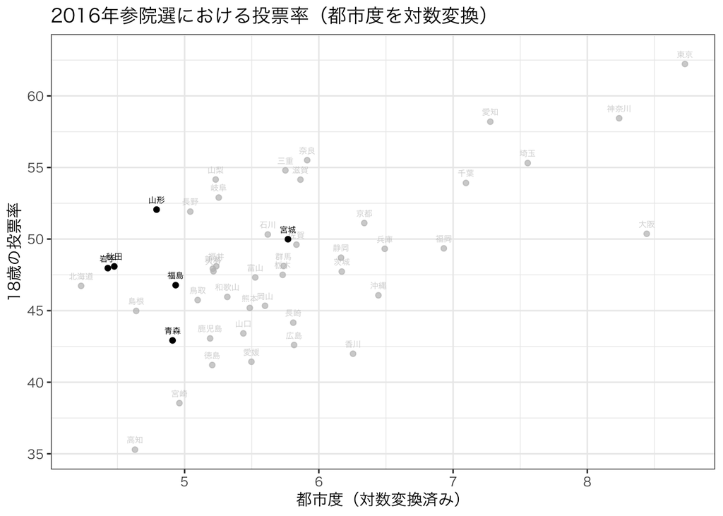

```r
hc2016 %>%
  ggplot(aes(log(did), age18)) +
  geom_point() +
  geom_text(aes(y = age18 + 0.7,
                label = pref),
            size = 2,
            family = "HiraKakuPro-W3") +
  labs(x = "都市度（対数変換済み）", y = "18歳の投票率") +
  ggtitle("2016年参院選における投票率（都市度を対数変換）") +
  theme_bw(base_family = "HiraKakuProN-W3") +
  gghighlight::gghighlight(
    pref == "青森"|
      pref == "秋田"|
      pref == "岩手"|
      pref == "山形"|
      pref == "宮城"|
      pref == "福島")
```

- `stat_smooth(method = lm)` を追加すれば、全都道府県の回帰直線と東北六県だけの回帰直線を同時に表示することもできる

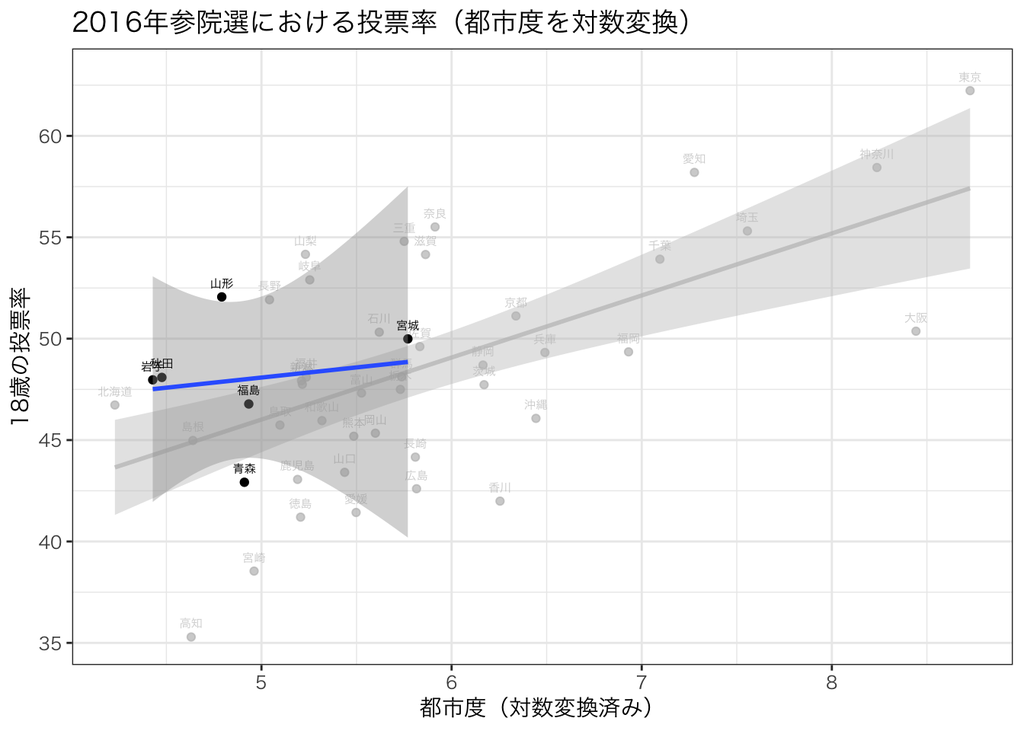

```r
hc2016 %>%
  ggplot(aes(log(did), age18)) +
  geom_point() +
  stat_smooth(method = lm) +
  geom_text(aes(y = age18 + 0.7,
                label = pref),
            size = 2,
            family = "HiraKakuPro-W3") +
  labs(x = "都市度（対数変換済み）", y = "18歳の投票率") +
  ggtitle("2016年参院選における投票率（都市度を対数変換）") +
  theme_bw(base_family = "HiraKakuProN-W3") +
  gghighlight::gghighlight(
    pref == "青森"|
      pref == "秋田"|
      pref == "岩手"|
      pref == "山形"|
      pref == "宮城"|
      pref == "福島")
```